# CS 422 - HW 8

Mark Gameng, Illinois Institute of Technology

## Part 2.1 KMeans

### (a)

The name of the animal should be omitted when clustering, and all the other attributes are important.

Yes, the data needs to be standardized and can be done in r using scale(data)

I cleaned up the data in text file, and the cleaned data is now in file19.csv

### (b)

```r
library(factoextra)
orig_df <- read.csv("file19.csv")
df <- orig_df
df$X <- NULL # remove X column -- the idx
df$Name <- NULL # remove Name
df.standardized <- scale(data.matrix(df))
```

### (b.i)

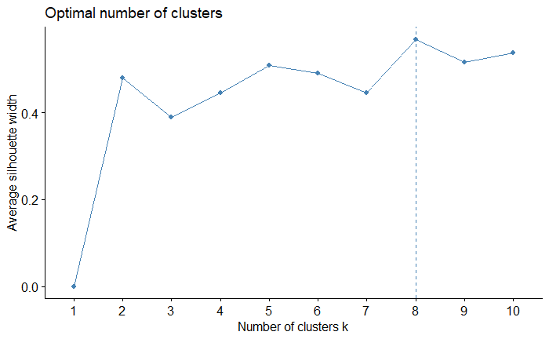

```r
fviz_nbclust(df.standardized, kmeans, method="silhouette")
```

```r
# 8 clusters
cat('8 Clusters are needed')
```

```
8 Clusters are needed
```

### (b.ii)

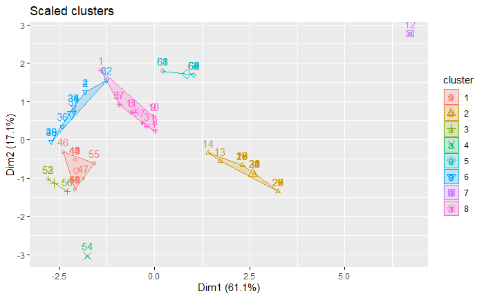

```r
k <- kmeans(df.standardized, center= 8)
fviz_cluster(k, data=df.standardized, main="Scaled clusters")
```

### (b.iii)

```r
clst <- c(1,2,3,4,5,6,7,8)
for (n in clst){
  cat(length(which(k$cluster == n)), "observations in cluster", n, "\n")
}
```

```
12 observations in cluster 1
19 observations in cluster 2
3 observations in cluster 3
1 observations in cluster 4
9 observations in cluster 5
11 observations in cluster 6
1 observations in cluster 7
10 observations in cluster 8
```

### (b.iv)

```r
cat(k$totss, "Total SSE")
```

```
520 Total SSE
```

### (b.v)

```r
cls_i = 1
for (x in k$withinss){
  cat(x, "SSE for cluster", cls_i, "\n")
  cls_i <- cls_i + 1
}
```

```
6.77 SSE for cluster 1
15.6 SSE for cluster 2
0.964 SSE for cluster 3
0 SSE for cluster 4
6.34 SSE for cluster 5
10.3 SSE for cluster 6
0 SSE for cluster 7
19 SSE for cluster 8
```

### (b.vi)

```r
clsss <- c(1,2,3,4,5,6,7,8)
for (x in clsss){
  cat("Cluster", x, "-", paste(orig_df[which(k$cluster == x), c('Name')], collapse = (", ")), "\n")
}
```

```
Cluster 1 - Weasel, Mink, Ferrer, Badger, Skunk, River otter, Sea otter, Jaguar, Ocelot, Cougar, Lynx, Grey seal
Cluster 2 - Pika, Snowshoe rabbit, Beaver, Marmot, Groundhog, Prairie Dog, Ground Squirrel, Chipmunk, Gray squirrel, Fox squirrel, Pocket gopher, Kangaroo rat, Pack rat, Field mouse, Muskrat, Black rat, House mouse, Porcupine, Guinea pig
Cluster 3 - Fur seal, Sea lion, Elephant seal
Cluster 4 - Walrus
Cluster 5 - Elk, Deer, Moose, Reindeer, Antelope, Bison, Mountain goat, Musk ox, Mountain sheep
Cluster 6 - Hairy tail mole, Star nose mole, Coyote, Wolf, Fox, Bear, Civet cat, Raccoon, Marten, Fisher, Wolverine
Cluster 7 - Armadillo
Cluster 8 - Opossum, Common mole, Brown bat, Silver hair bat, Pigmy bat, House bat, Red bat, Hoary bat, Lump nose bat, Peccary
```

Looking at the animals in each cluster, they somewhat makes sense. The only cluster I feel that have some animals that don’t make sense is cluster 1. Cluster 1 has weasels, badgers, otters, seals, jaguars and ocelots in one cluster, which I find quite weird. However, I am going based on appearances, so according to their attributes, this cluster might have made sense. Thus, these resulting clusters makes sense and it met expectations.

## Part 2.2 dbscan

### (a)

```r
library(dbscan)
library(fpc)
library(factoextra)
s1 <- read.csv("s1.csv")
s1
```

| x | y |
| --- | --- |
| 664159 | 550946 |
| 665845 | 557965 |
| 597173 | 575538 |
| 618600 | 551446 |
| 635690 | 608046 |
| 588100 | 557588 |
| 582015 | 546191 |
| 604678 | 574577 |
| 572029 | 518313 |
| 604737 | 574591 |

[output cut: 990 more lines]

```r
s1.scaled <- scale(s1)
```

I think its necessary to standardize the data due to how large the numbers are and also, generally you should ‘always’ scale data.

### (b)

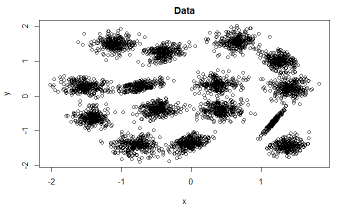

```r
plot(s1.scaled, main="Data")
```

### (b.ii)

From the plot, I see 15 clusters, and I found them to be somewhat well-separated.

### (c.i)

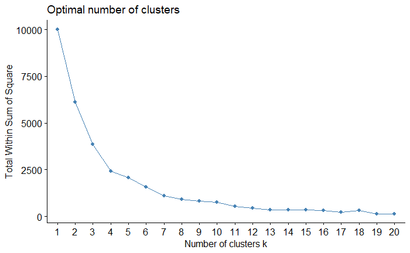

```r
fviz_nbclust(s1.scaled, kmeans, method="wss", k.max = 20)
```

### (c.ii)

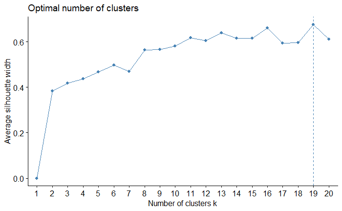

```r
fviz_nbclust(s1.scaled, kmeans, method="silhouette", k.max = 20)
```

### (d)

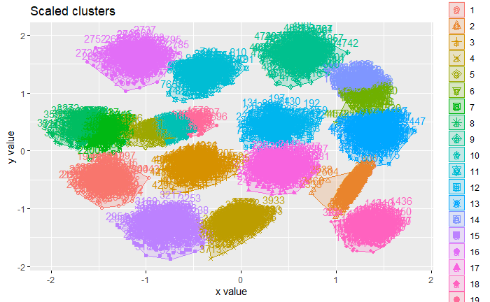

```r
k <- kmeans(s1.scaled, center= 19)
fviz_cluster(k, data=s1.scaled, main="Scaled clusters")
```

### (d.ii)

Kmeans clustered the data somewhat well except for certain parts. There is 2 parts that should just be one cluster, but Kmeans split it to 3 and 2 clusters. Also it results in 19 clusters, where it should be more near or equals 15 clusters.

### (e.i)

I think MinPts = 6 is reasonable for this dataset because of how many points are quite “outside” of the clusters.

### (e.ii)

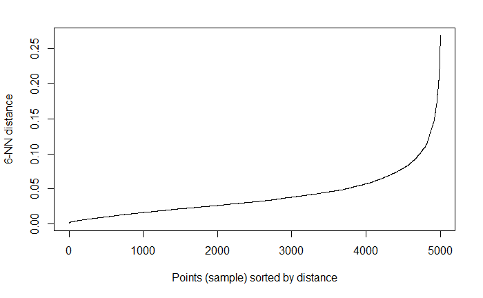

```r
kNNdistplot(s1.scaled, k = 6)
```

It seems that the value for eps is around 0.08. So I am going to try 0.075, 0.08, 0.085 and see which one results in the best one.

I found 0.08 to be the best eps value as it results in 15 clusters.

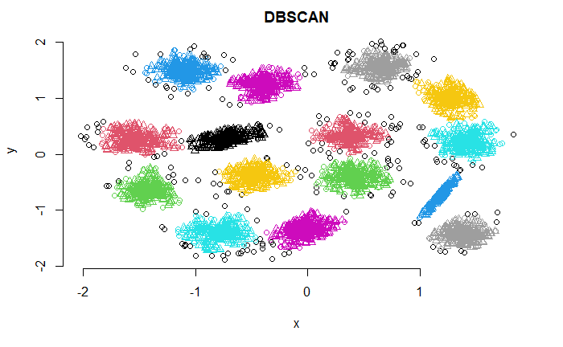

```r
db <- fpc::dbscan(s1.scaled, eps = 0.08, MinPts = 6)
plot(db, s1.scaled, main = "DBSCAN", frame = FALSE)
```

```r
#print(db)
cat("At minPts = 6, eps = 0.08, there are 15 clusters")
```

```
At minPts = 6, eps = 0.08, there are 15 clusters
```